# DATS 6101 - Midterm

### Content Rating, Last Updated

```r
# Remove leading and trailing spaces and convert all text to a consistent format
data_final$Content.Rating <- trimws(tolower(data_final$Content.Rating))

cr_missing <- sum(is.na(data_final$`Content Rating`))

print(paste("Number of missing values in 'Content Rating':", cr_missing))
```

```
## [1] "Number of missing values in 'Content Rating': 0"
```

There are no missing values for Content rating.

```r
# Convert Last Updated to Date format
data_final$Last.Updated <- as.Date(data_final$Last.Updated, format = "%B %d, %Y")

# Verify the cleaning
print("\nSummary of Last.Updated after cleaning:")
```

```
## [1] "\nSummary of Last.Updated after cleaning:"
```

```r
print(summary(data_clean$Last.Updated))
```

```
##    Length     Class      Mode
##      6979 character character
```

```r
# 1. Content Rating Distribution
content_rating_dist <- table(data_final$Content.Rating)
print("Content Rating Distribution:")
```

```
## [1] "Content Rating Distribution:"
```

```r
print(content_rating_dist)
```

```
##
## adults only 18+        everyone    everyone 10+      mature 17+            teen
##               2            5766             221             264             712
##         unrated
##               1
```

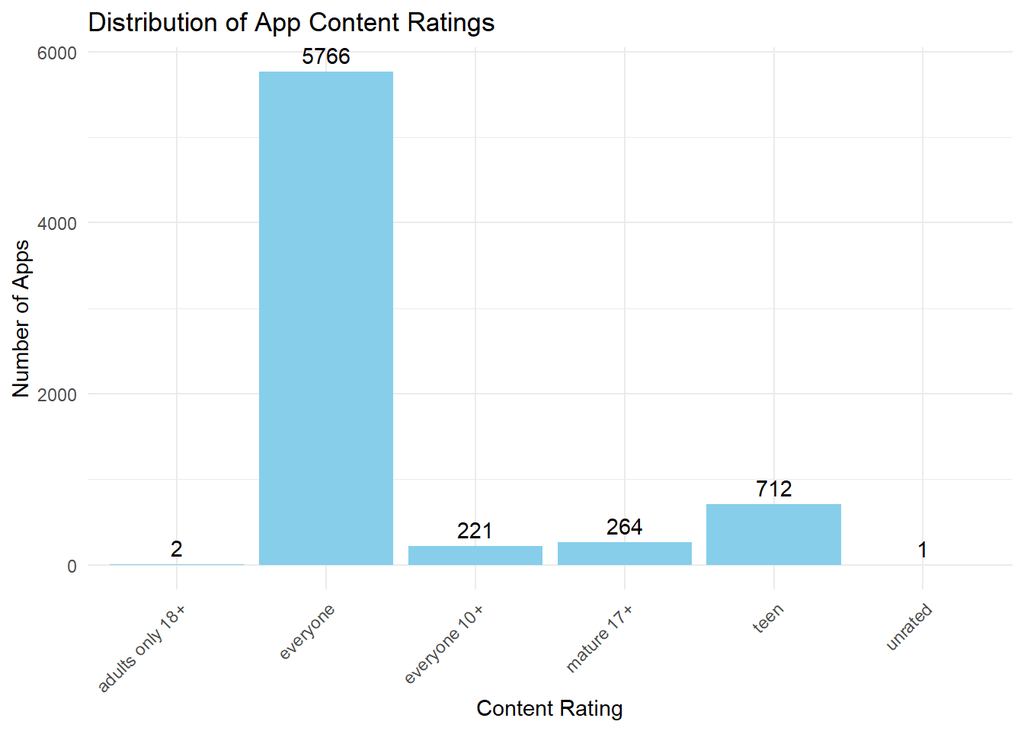

```r
# Bar plot for Content Rating
ggplot(data_final, aes(x = Content.Rating)) +
  geom_bar(fill = "skyblue") +
  geom_text(stat = "count", aes(label = ..count..), vjust = -0.5) +
  labs(title = "Distribution of App Content Ratings",
       x = "Content Rating",
       y = "Number of Apps") +
  theme_minimal() +
  theme(axis.text.x = element_text(angle = 45, hjust = 1))
```

Frequency of different content ratings assigned to a set of apps, each bar represents the count of apps for a specific content rating category

```r
# Last Updated Analysis
# Create summary of updates by month and year
updates_by_month <- data_final %>%
  mutate(
    update_month = format(Last.Updated, "%Y-%m"),
    update_year = year(Last.Updated)
  ) %>%
  group_by(update_month) %>%
  summarize(count = n()) %>%
  arrange(update_month)
```

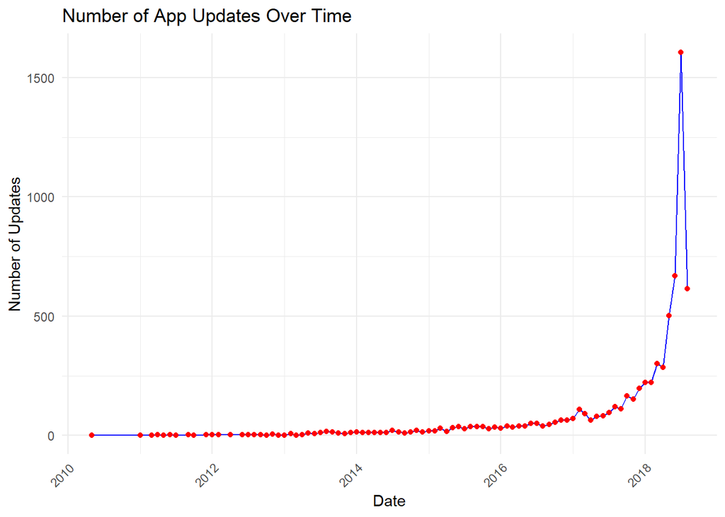

```r
# Plot updates over time
ggplot(updates_by_month, aes(x = as.Date(paste0(update_month, "-01")), y = count)) +
  geom_line(color = "blue") +
  geom_point(color = "red") +
  labs(title = "Number of App Updates Over Time",
       x = "Date",
       y = "Number of Updates") +
  theme_minimal() +
  theme(axis.text.x = element_text(angle = 45, hjust = 1))
```

The number of updates have drastically increased from the end of 2017

```r
# Content Rating and Update Frequency Relationship
update_frequency_by_rating <- data_final %>%
  group_by(Content.Rating) %>%
  summarize(
    avg_last_update = mean(Last.Updated),
    median_last_update = median(Last.Updated),
    n_apps = n()
  )
print("\nUpdate Frequency by Content Rating:")
```

```
## [1] "\nUpdate Frequency by Content Rating:"
```

```r
print(update_frequency_by_rating)
```

```
## # A tibble: 6 × 4
##   Content.Rating  avg_last_update median_last_update n_apps
##   <chr>           <date>          <date>              <int>
## 1 adults only 18+ 2018-07-14      2018-07-14              2
## 2 everyone        2017-09-30      2018-04-09           5766
## 3 everyone 10+    2017-12-06      2018-06-02            221
## 4 mature 17+      2018-01-29      2018-07-03            264
## 5 teen            2017-11-09      2018-05-24            712
## 6 unrated         2015-06-24      2015-06-24              1
```

```r
# Chi-square test for independence
# Creating contingency table of Content Rating vs Update Year
content_update_table <- table(
  data_final$Content.Rating,
  year(data_final$Last.Updated)
)
chi_test <- chisq.test(content_update_table)
print("\nChi-square test results:")
```

```
## [1] "\nChi-square test results:"
```

```r
print(chi_test)
```

```
##
##  Pearson's Chi-squared test
##
## data:  content_update_table
## X-squared = 65.016, df = 40, p-value = 0.00745
```

The P value is small signifying that there is statistically significant relationship between Content Rating and Last Updated Columns

```r
# Content Rating Basic Analysis
print("Basic Content Rating Analysis:")
```

```
## [1] "Basic Content Rating Analysis:"
```

```r
content_rating_counts <- table(data_final$Content.Rating)
print(content_rating_counts)
```

```
##
## adults only 18+        everyone    everyone 10+      mature 17+            teen
##               2            5766             221             264             712
##         unrated
##               1
```

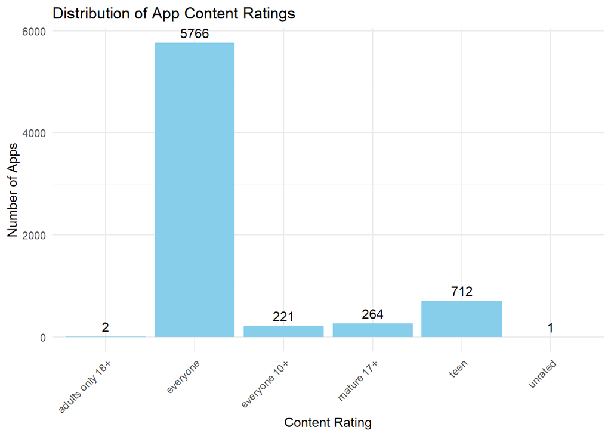

```r
# Basic bar plot for Content Rating
ggplot(data_final, aes(x = Content.Rating)) +
  geom_bar(fill = "skyblue") +
  geom_text(stat = "count", aes(label = ..count..), vjust = -0.5) +
  labs(title = "Distribution of App Content Ratings",
       x = "Content Rating",
       y = "Number of Apps") +
  theme_minimal() +
  theme(axis.text.x = element_text(angle = 45, hjust = 1))
```

```r
# Calculate percentages
content_rating_percentages <- prop.table(content_rating_counts) * 100
print("\nContent Rating Percentages:")
```

```
## [1] "\nContent Rating Percentages:"
```

```r
print(round(content_rating_percentages, 2))
```

```
##
## adults only 18+        everyone    everyone 10+      mature 17+            teen
##            0.03           82.77            3.17            3.79           10.22
##         unrated
##            0.01
```

```r
# 1.2 Last Updated Basic Analysis
data_final$Last.Updated <- as.Date(data_final$Last.Updated, format = "%B %d, %Y")

print("\nLast Updated Summary Statistics:")
```

```
## [1] "\nLast Updated Summary Statistics:"
```

```r
summary(data_final$Last.Updated)
```

```
##         Min.      1st Qu.       Median         Mean      3rd Qu.         Max.
## "2010-05-21" "2017-07-12" "2018-04-21" "2017-10-11" "2018-07-13" "2018-08-08"
```

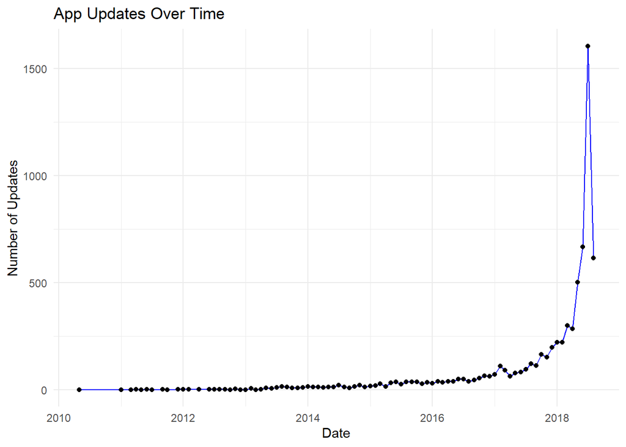

```r
# Time-based Analysis
data_final <- data_final %>%
  mutate(
    update_year = year(Last.Updated),
    update_month = month(Last.Updated),
    update_quarter = quarter(Last.Updated),
    days_since_update = as.numeric(difftime(max(Last.Updated), Last.Updated, units = "days"))
  )

# Monthly update pattern
monthly_updates <- data_final %>%
  group_by(update_year, update_month) %>%
  summarize(count = n()) %>%
  mutate(date = as.Date(paste(update_year, update_month, "01", sep = "-")))

ggplot(monthly_updates, aes(x = date, y = count)) +
  geom_line(color = "blue") +
  geom_point() +
  labs(title = "App Updates Over Time",
       x = "Date",
       y = "Number of Updates") +
  theme_minimal()
```

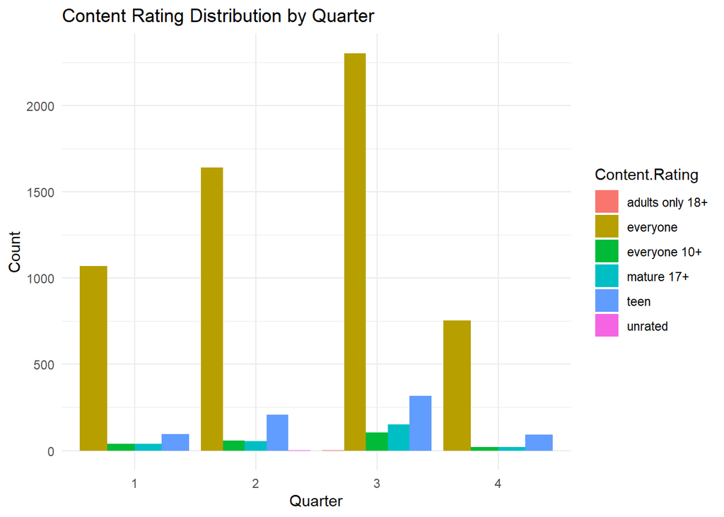

```r
# 2.2 Content Rating Distribution by Update Quarter
ggplot(data_final, aes(x = factor(update_quarter), fill = Content.Rating)) +
  geom_bar(position = "dodge") +
  labs(title = "Content Rating Distribution by Quarter",
       x = "Quarter",
       y = "Count") +
  theme_minimal()
```

```r
# 3.1 Update Frequency Analysis by Content Rating
update_patterns <- data_final %>%
  group_by(Content.Rating) %>%
  summarize(
    avg_days_since_update = mean(days_since_update),
    median_days_since_update = median(days_since_update),
    sd_days_since_update = sd(days_since_update),
    n_apps = n()
  ) %>%
  arrange(avg_days_since_update)

print("\nUpdate Patterns by Content Rating:")
```

```
## [1] "\nUpdate Patterns by Content Rating:"
```

```r
print(update_patterns)
```

```
## # A tibble: 6 × 5
##   Content.Rating  avg_days_since_update median_days_since_update
##   <chr>                           <dbl>                    <dbl>
## 1 adults only 18+                   25                      25
## 2 mature 17+                       191.                     35.5
## 3 everyone 10+                     244.                     67
## 4 teen                             271.                     76
## 5 everyone                         312.                    121
## 6 unrated                         1141                    1141
## # ℹ 2 more variables: sd_days_since_update <dbl>, n_apps <int>
```

```r
# 3.2 Statistical Tests

# Chi-square test for independence
contingency_table <- table(data_final$Content.Rating, data_final$update_quarter)
chi_test <- chisq.test(contingency_table)
print("\nChi-square test for independence between Content Rating and Update Quarter:")
```

```
## [1] "\nChi-square test for independence between Content Rating and Update Quarter:"
```

```r
print(chi_test)
```

```
##
##  Pearson's Chi-squared test
##
## data:  contingency_table
## X-squared = 54.341, df = 15, p-value = 2.304e-06
```

[figure not shown]

```r
# 3.3 Advanced Visualization - Heatmap of Updates
update_heatmap_data <- data_final %>%
  group_by(update_month, Content.Rating) %>%
  summarize(count = n()) %>%
  spread(Content.Rating, count)

# Convert to matrix for heatmap
update_matrix <- as.matrix(update_heatmap_data[,-1])
rownames(update_matrix) <- month.abb[update_heatmap_data$update_month]

# Create heatmap
heatmap(update_matrix,
        Colv = NA,
        Rowv = NA,
        scale = "column",
        col = colorRampPalette(c("white", "steelblue"))(50),
        main = "Update Pattern Heatmap by Content Rating",
        xlab = "Content Rating",
        ylab = "Month")
```

[figure not shown]

```r
# 3.4 Time Series Decomposition
# Focus on Everyone category as an example
everyone_ts <- monthly_updates %>%
  filter(count > 0) %>%
  select(count) %>%
  ts(frequency = 12)

decomposed <- decompose(everyone_ts)
plot(decomposed)
```

```r
# 3.5 Update Velocity Analysis
update_velocity <- data_final %>%
  group_by(Content.Rating) %>%
  summarize(
    update_velocity = n() / n_distinct(update_month),
    total_apps = n()
  ) %>%
  arrange(desc(update_velocity))

print("\nUpdate Velocity by Content Rating:")
```

```
## [1] "\nUpdate Velocity by Content Rating:"
```

```r
print(update_velocity)
```

```
## # A tibble: 6 × 3
##   Content.Rating  update_velocity total_apps
##   <chr>                     <dbl>      <int>
## 1 everyone                  480.        5766
## 2 teen                       59.3        712
## 3 mature 17+                 22          264
## 4 everyone 10+               18.4        221
## 5 adults only 18+             2            2
## 6 unrated                     1            1
```

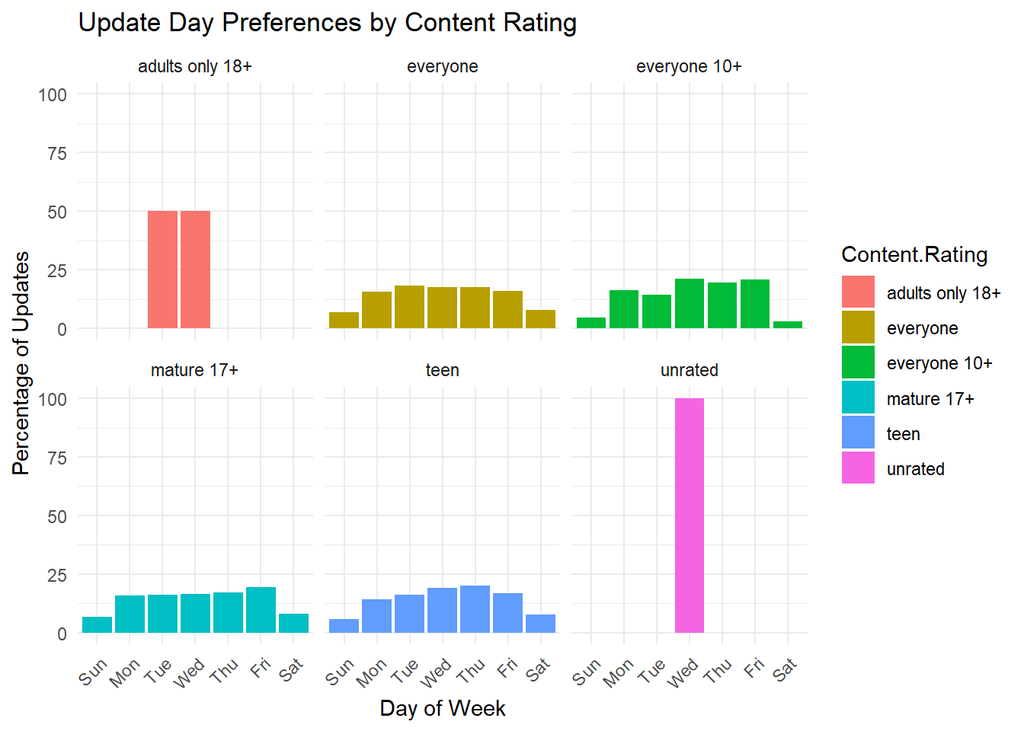

```r
# 1. Update Cycle Analysis
data_final <- data_final %>%
  mutate(
    Last.Updated = as.Date(Last.Updated, format = "%B %d, %Y"),
    day_of_week = wday(Last.Updated, label = TRUE),
    week_of_year = week(Last.Updated),
    month_of_year = month(Last.Updated, label = TRUE),
    season = case_when(
      month_of_year %in% c("Dec", "Jan", "Feb") ~ "Winter",
      month_of_year %in% c("Mar", "Apr", "May") ~ "Spring",
      month_of_year %in% c("Jun", "Jul", "Aug") ~ "Summer",
      TRUE ~ "Fall"
    )
  )

# Day of Week Update Pattern by Content Rating
dow_pattern <- data_final %>%
  group_by(Content.Rating, day_of_week) %>%
  summarise(count = n()) %>%
  group_by(Content.Rating) %>%
  mutate(percentage = count/sum(count) * 100)

ggplot(dow_pattern, aes(x = day_of_week, y = percentage, fill = Content.Rating)) +
  geom_bar(stat = "identity", position = "dodge") +
  facet_wrap(~Content.Rating) +
  labs(title = "Update Day Preferences by Content Rating",
       x = "Day of Week",
       y = "Percentage of Updates") +
  theme_minimal() +
  theme(axis.text.x = element_text(angle = 45, hjust = 1))
```

```r
# 2. Update Interval Analysis
update_intervals <- data_final %>%
  group_by(Content.Rating) %>%
  arrange(Last.Updated) %>%
  mutate(days_between_updates = as.numeric(Last.Updated - lag(Last.Updated))) %>%
  summarise(
    mean_interval = mean(days_between_updates, na.rm = TRUE),
    median_interval = median(days_between_updates, na.rm = TRUE),
    std_dev = sd(days_between_updates, na.rm = TRUE),
    cv = std_dev / mean_interval * 100  # Coefficient of Variation
  )

print("Update Interval Analysis:")
```

```
## [1] "Update Interval Analysis:"
```

```r
print(update_intervals)
```

```
## # A tibble: 6 × 5
##   Content.Rating  mean_interval median_interval std_dev    cv
##   <chr>                   <dbl>           <dbl>   <dbl> <dbl>
## 1 adults only 18+        20                  20   NA      NA
## 2 everyone                0.521               0    4.15  797.
## 3 everyone 10+           12.2                 1   61.9   509.
## 4 mature 17+              8.16                1   28.0   343.
## 5 teen                    3.43                0   17.9   521.
## 6 unrated               NaN                  NA   NA      NA
```

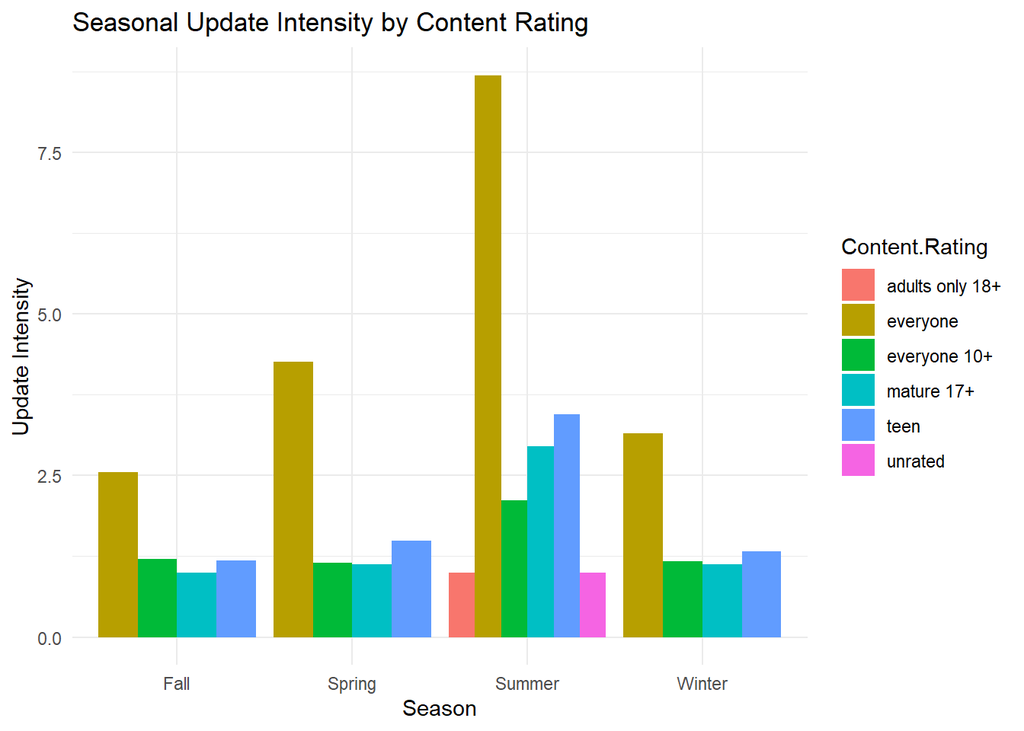

```r
# 3. Seasonal Update Intensity
seasonal_intensity <- data_final %>%
  group_by(Content.Rating, season) %>%
  summarise(
    update_count = n(),
    update_intensity = n() / n_distinct(Last.Updated)
  ) %>%
  arrange(Content.Rating, desc(update_intensity))

# Visualization of seasonal patterns
ggplot(seasonal_intensity, aes(x = season, y = update_intensity, fill = Content.Rating)) +
  geom_bar(stat = "identity", position = "dodge") +
  labs(title = "Seasonal Update Intensity by Content Rating",
       x = "Season",
       y = "Update Intensity") +
  theme_minimal()
```

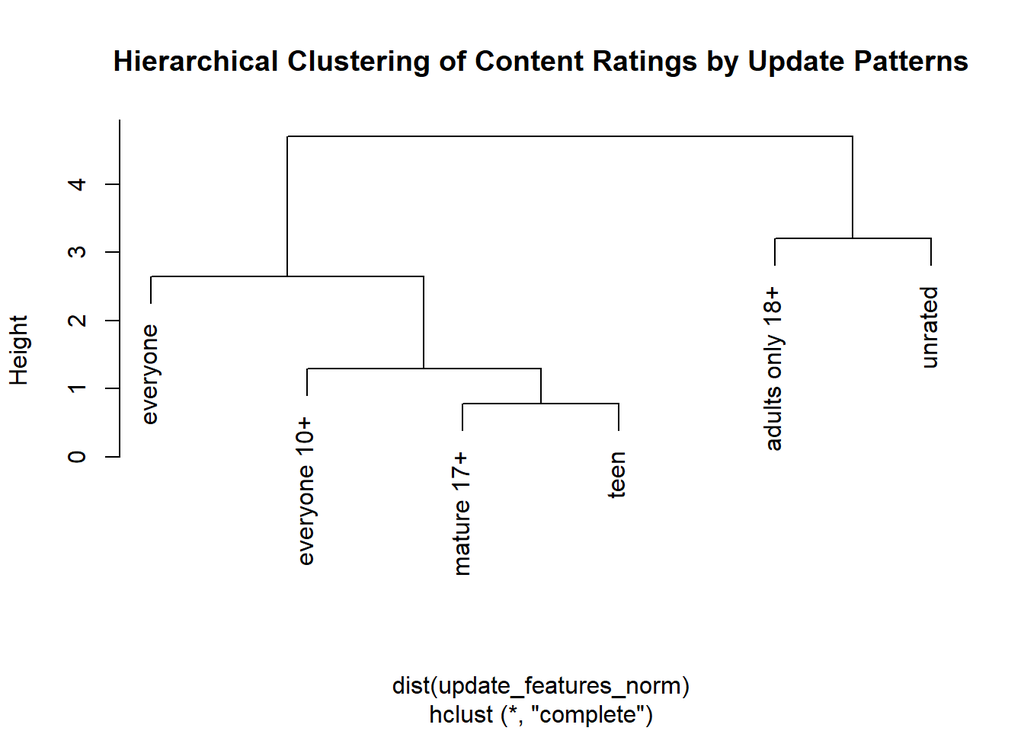

```r
# 4. Update Clustering Analysis
update_features <- data_final %>%
  group_by(Content.Rating) %>%
  summarise(
    mean_week = mean(week_of_year),
    std_week = sd(week_of_year),
    update_frequency = n(),
    weekend_ratio = sum(day_of_week %in% c("Sat", "Sun")) / n()
  )

# Normalize the features
update_features_norm <- scale(update_features[,-1])
rownames(update_features_norm) <- update_features$Content.Rating

# Perform hierarchical clustering
update_clusters <- hclust(dist(update_features_norm))
plot(update_clusters, main = "Hierarchical Clustering of Content Ratings by Update Patterns")
```

```r
# 6. Update Consistency Score
consistency_score <- data_final %>%
  group_by(Content.Rating) %>%
  summarise(
    total_updates = n(),
    unique_days = n_distinct(Last.Updated),
    consistency_score = (total_updates / unique_days) *
      (1 - sd(as.numeric(day_of_week)) / 7)  # Normalized consistency metric
  ) %>%
  arrange(desc(consistency_score))

print("\nUpdate Consistency Scores:")
```

```
## [1] "\nUpdate Consistency Scores:"
```

```r
print(consistency_score)
```

```
## # A tibble: 6 × 4
##   Content.Rating  total_updates unique_days consistency_score
##   <chr>                   <int>       <int>             <dbl>
## 1 everyone                 5766        1196             3.64
## 2 teen                      712         349             1.55
## 3 mature 17+                264         141             1.40
## 4 everyone 10+              221         141             1.21
## 5 adults only 18+             2           2             0.899
## 6 unrated                     1           1            NA
```

```r
# Convert Last.Updated to numeric (days since reference date) if not already done
reference_date <- min(data_final$Last.Updated, na.rm = TRUE)  # Reference date
data_final$Days.Since.Update <- as.numeric(data_final$Last.Updated - reference_date)

# Perform the Kolmogorov-Smirnov test on the numeric 'Days.Since.Update' values
content_ratings <- unique(data_final$Content.Rating)
ks_results <- data.frame(
  rating1 = character(),
  rating2 = character(),
  p_value = numeric()
)

for (i in 1:(length(content_ratings)-1)) {
  for (j in (i+1):length(content_ratings)) {
    # Extract groups, removing NA values
    group1 <- na.omit(data_final$Days.Since.Update[data_final$Content.Rating == content_ratings[i]])
    group2 <- na.omit(data_final$Days.Since.Update[data_final$Content.Rating == content_ratings[j]])

    # Check if both groups have enough data for comparison
    if(length(group1) > 1 && length(group2) > 1) {
      ks_test <- ks.test(group1, group2)
      ks_results <- rbind(ks_results,
                          data.frame(rating1 = content_ratings[i],
                                     rating2 = content_ratings[j],
                                     p_value = ks_test$p.value))
    }
  }
}

print("\nKolmogorov-Smirnov Test Results:")
```

```
## [1] "\nKolmogorov-Smirnov Test Results:"
```

```r
print(ks_results[ks_results$p_value < 0.05,])
```

```
##        rating1      rating2      p_value
## 1         teen     everyone 1.371119e-04
## 3         teen   mature 17+ 3.224215e-05
## 5     everyone everyone 10+ 1.151234e-03
## 6     everyone   mature 17+ 1.902397e-12
## 8 everyone 10+   mature 17+ 8.647877e-03
```

```r
# Clean and prepare the Installs column
data_final <- data_final %>%
  mutate(
    # Convert Last.Updated to Date format if not already
    Last.Updated = as.Date(Last.Updated, format = "%B %d, %Y"),
    # Convert Content.Rating to factor
    Content.Rating = as.factor(Content.Rating)
  )
```

```r
# 1. Basic statistics for Installs by Content Rating
installs_by_rating <- data_final %>%
  group_by(Content.Rating) %>%
  summarise(
    mean_installs = mean(Installs, na.rm = TRUE),
    median_installs = median(Installs, na.rm = TRUE),
    total_installs = sum(Installs, na.rm = TRUE),
    n_apps = n()
  ) %>%
  arrange(desc(mean_installs))

print("Summary of Installs by Content Rating:")
```

```
## [1] "Summary of Installs by Content Rating:"
```

```r
print(installs_by_rating)
```

```
## # A tibble: 6 × 5
##   Content.Rating  mean_installs median_installs total_installs n_apps
##   <fct>                   <dbl>           <dbl>          <dbl>  <int>
## 1 everyone 10+        13142477.         1000000     2904487480    221
## 2 teen                 6742902.          500000     4800946402    712
## 3 everyone             3734327.           10000    21532131197   5766
## 4 mature 17+           3279775.          500000      865860638    264
## 5 adults only 18+       750000           750000        1500000      2
## 6 unrated                  500              500            500      1
```

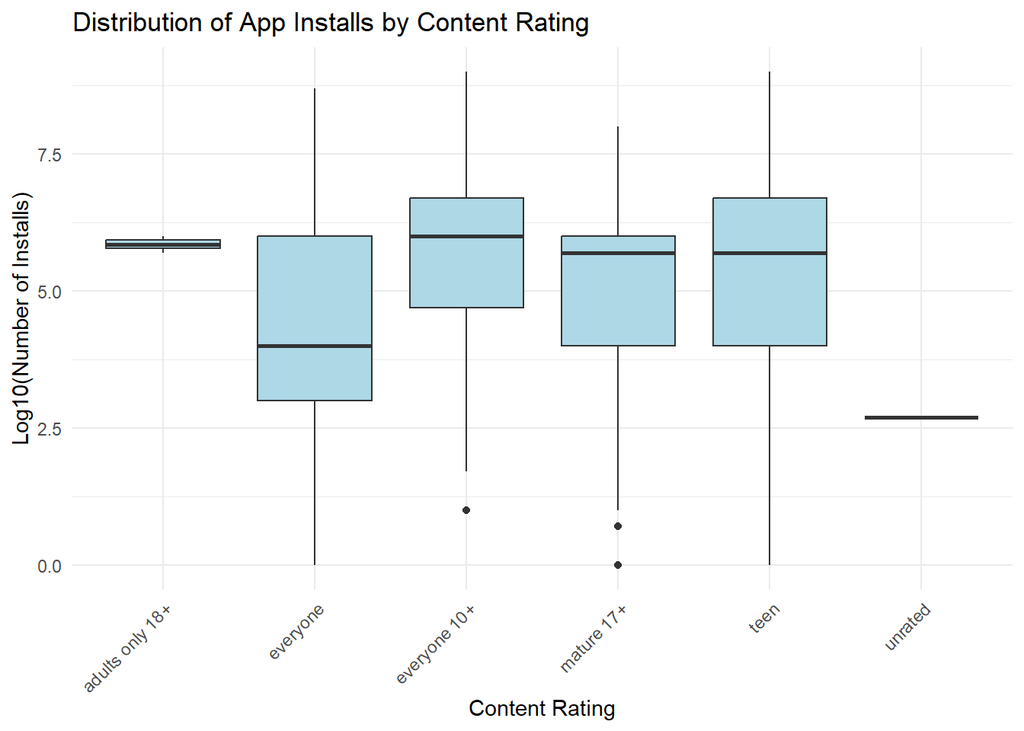

```r
# 2. Visualize distribution of installs by content rating
ggplot(data_final, aes(x = Content.Rating, y = log10(Installs))) +
  geom_boxplot(fill = "lightblue") +
  labs(title = "Distribution of App Installs by Content Rating",
       x = "Content Rating",
       y = "Log10(Number of Installs)") +
  theme_minimal() +
  theme(axis.text.x = element_text(angle = 45, hjust = 1))
```

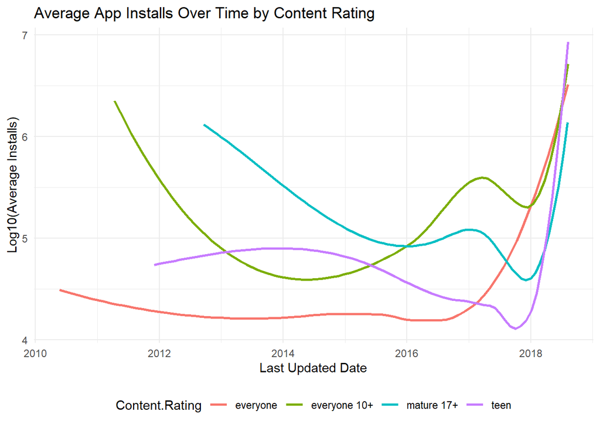

```r
# 3. Timeline analysis: Average installs over time by content rating
installs_timeline <- data_final %>%
  group_by(Content.Rating, Last.Updated) %>%
  summarise(avg_installs = mean(Installs, na.rm = TRUE)) %>%
  ungroup()

ggplot(installs_timeline, aes(x = Last.Updated, y = log10(avg_installs), color = Content.Rating)) +
  geom_smooth(method = "loess", se = FALSE) +
  labs(title = "Average App Installs Over Time by Content Rating",
       x = "Last Updated Date",
       y = "Log10(Average Installs)") +
  theme_minimal() +
  theme(legend.position = "bottom")
```

```r
# Remove rows where Installs has NA, NaN, or non-positive values (because log10 of 0 or negative is undefined)
data_final <- data_final %>%
  filter(!is.na(Installs) & Installs > 0)

# ANOVA test for difference in installs between content ratings
install_anova <- aov(log10(Installs) ~ Content.Rating, data = data_final)

print("\nANOVA test results for Installs by Content Rating:")
```

```
## [1] "\nANOVA test results for Installs by Content Rating:"
```

```r
print(summary(install_anova))
```

```
##                  Df Sum Sq Mean Sq F value Pr(>F)
## Content.Rating    5    663  132.63   39.52 <2e-16 ***
## Residuals      6960  23361    3.36
## ---
## Signif. codes:  0 '***' 0.001 '**' 0.01 '*' 0.05 '.' 0.1 ' ' 1
```

```r
# 5. Create time-based features for correlation analysis
data_analysis <- data_final %>%
  mutate(
    days_since_update = as.numeric(difftime(max(Last.Updated), Last.Updated, units = "days")),
    update_year = year(Last.Updated),
    update_month = month(Last.Updated)
  )

# Calculate correlation between days since update and installs
correlation_result <- cor.test(data_analysis$days_since_update,
                             log10(data_analysis$Installs),
                             method = "spearman")

print("\nCorrelation between days since update and installs:")
```

```
## [1] "\nCorrelation between days since update and installs:"
```

```r
print(correlation_result)
```

```
##
##  Spearman's rank correlation rho
##
## data:  data_analysis$days_since_update and log10(data_analysis$Installs)
## S = 7.2211e+10, p-value < 2.2e-16
## alternative hypothesis: true rho is not equal to 0
## sample estimates:
##       rho
## -0.281761
```

```r
# 6. Recent vs Old updates comparison
data_analysis <- data_analysis %>%
  mutate(update_recency = ifelse(days_since_update <= median(days_since_update),
                                "Recent Update", "Old Update"))

recent_vs_old <- data_analysis %>%
  group_by(Content.Rating, update_recency) %>%
  summarise(
    mean_installs = mean(Installs, na.rm = TRUE),
    median_installs = median(Installs, na.rm = TRUE),
    n_apps = n()
  )

print("\nComparison of Installs by Update Recency and Content Rating:")
```

```
## [1] "\nComparison of Installs by Update Recency and Content Rating:"
```

```r
print(recent_vs_old)
```

```
## # A tibble: 10 × 5
## # Groups:   Content.Rating [6]
##    Content.Rating  update_recency mean_installs median_installs n_apps
##    <fct>           <chr>                  <dbl>           <dbl>  <int>
##  1 adults only 18+ Recent Update        750000           750000      2
##  2 everyone        Old Update          1202045.           10000   2985
##  3 everyone        Recent Update       6452365.          100000   2781
##  4 everyone 10+    Old Update          2717872.          100000     92
##  5 everyone 10+    Recent Update      20577080.         1000000    129
##  6 mature 17+      Old Update          1046779.          100000     88
##  7 mature 17+      Recent Update       4396273.          500000    176
##  8 teen            Old Update          1200671.           50000    316
##  9 teen            Recent Update      11165491.         1000000    396
## 10 unrated         Old Update              500              500      1
```

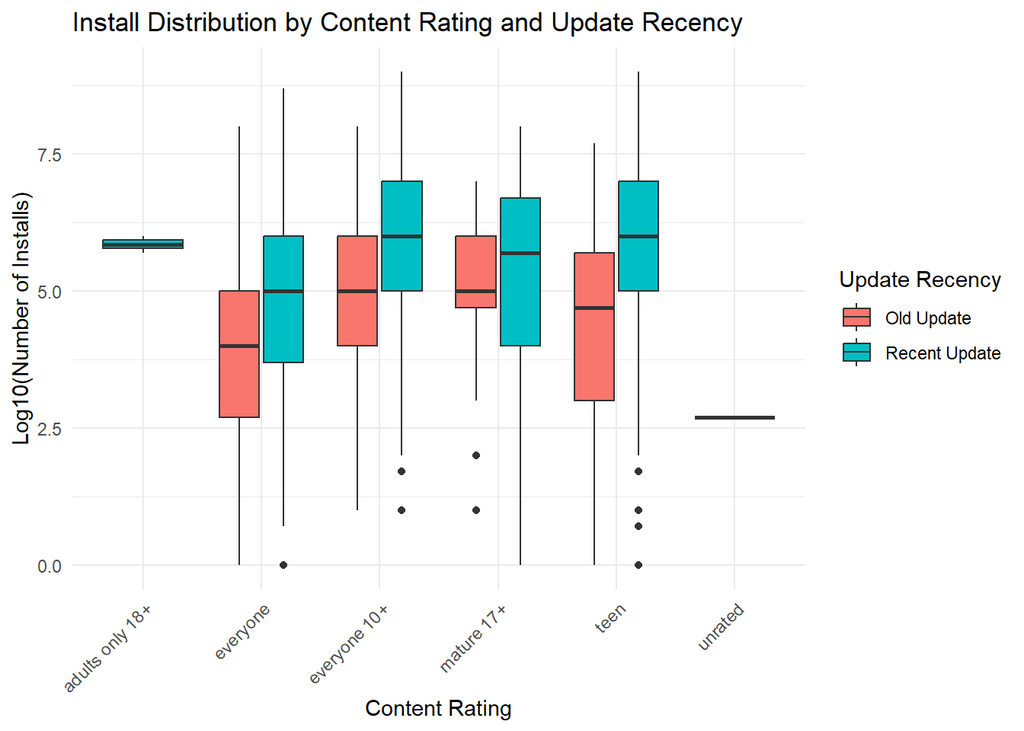

```r
# 7. Visualization of update recency effect
ggplot(data_analysis, aes(x = Content.Rating, y = log10(Installs), fill = update_recency)) +
  geom_boxplot() +
  labs(title = "Install Distribution by Content Rating and Update Recency",
       x = "Content Rating",
       y = "Log10(Number of Installs)",
       fill = "Update Recency") +
  theme_minimal() +
  theme(axis.text.x = element_text(angle = 45, hjust = 1))
```

```r
# 1. Encode content rating (e.g., as factor levels or one-hot encoding)
data_final$Content.Rating <- as.factor(data_final$Content.Rating)

# 2. Create days since last update
data_final$days_since_update <- as.numeric(difftime(Sys.Date(), data_final$Last.Updated, units = "days"))

# 3. Calculate correlations
# Log-transform installs for better normalization
data_final$log_installs <- log10(data_final$Installs)

# Correlation between days since update and installs
correlation_update_installs <- cor.test(data_final$days_since_update, data_final$log_installs, method = "spearman")

# ANOVA for installs based on content rating
anova_content_rating <- aov(log_installs ~ Content.Rating, data = data_final)

# Print results
print(correlation_update_installs)
```

```
##
##  Spearman's rank correlation rho
##
## data:  data_final$days_since_update and data_final$log_installs
## S = 7.2211e+10, p-value < 2.2e-16
## alternative hypothesis: true rho is not equal to 0
## sample estimates:
##       rho
## -0.281761
```

```r
print(summary(anova_content_rating))
```

```
##                  Df Sum Sq Mean Sq F value Pr(>F)
## Content.Rating    5    663  132.63   39.52 <2e-16 ***
## Residuals      6960  23361    3.36
## ---
## Signif. codes:  0 '***' 0.001 '**' 0.01 '*' 0.05 '.' 0.1 ' ' 1
```

### Implications

These findings suggest that regular updates are important for sustaining app installs, and that different content ratings can influence user engagement. Strategies aimed at timely updates and optimizing content ratings could enhance app performance and user acquisition.